# *SignalingProfiler* 2.0 Step 3 benchmarking

Veronica Venafra

## Introduction

This workbook refers to the manuscript *SignalingProfiler 2.0: a network-based approach to bridge multi-omic data to phenotypic hallmarks*.

## Import libraries and functions

```r
source('0.libraries.R')
source('0.functions.R')

network_dir <- './results/4.network_generation/'
pheno_dir <- './results/5.phenoscore_benchmarking/'
```

## Definition of all combinations of technical parameters

```r
# Chose wheter preprocess ProxPath paths over experimental data
preprocess <- c(TRUE, FALSE)

# Possible shortest paths length from phenotypic regulators to phenotypes
path_length <- c(2,3,4)

# Choose Z-score metric
stat <- c('mean', 'median')

# In cases where multiple proteins influence a common phenotype and one protein
# in the SignalingProfiler optimized model is downstream another,
# choose whether considering only the most downstream protein as a phenotypic regulator
remove_cascade <- c(TRUE, FALSE)

# To take into account that a protein with a higher count of paths
# over a phenotype is more redundant and consequently a stronger regulator
node_idx <- c(TRUE, FALSE)

# The activity of each phenotype regulator can be based on the activity of nodes
# computed by CARNIVAL or by algorithms of Step1 (final activity score)
use_carnival_activity = c(TRUE, FALSE)

list('preprocess' = preprocess,
     'path_length' = path_length,
     'stat' = stat,
     'remove_cascade' = remove_cascade,
     'node_idx' = node_idx,
     'use_carnival_activity' = use_carnival_activity) -> phenoscore_params

expand.grid(phenoscore_params) -> phenoscore_params_df

phenoscore_params_df$pheno_id <- paste0('Pheno', 1:nrow(phenoscore_params_df))
#write_tsv(phenoscore_params_df, paste0(pheno_dir, 'pheno_annotation_df.tsv'))

head(phenoscore_params_df)
```

```
##   preprocess path_length stat remove_cascade node_idx use_carnival_activity
## 1       TRUE           2 mean           TRUE     TRUE                  TRUE
## 2      FALSE           2 mean           TRUE     TRUE                  TRUE
## 3       TRUE           3 mean           TRUE     TRUE                  TRUE
## 4      FALSE           3 mean           TRUE     TRUE                  TRUE
## 5       TRUE           4 mean           TRUE     TRUE                  TRUE
## 6      FALSE           4 mean           TRUE     TRUE                  TRUE
##   pheno_id
## 1   Pheno1
## 2   Pheno2
## 3   Pheno3
## 4   Pheno4
## 5   Pheno5
## 6   Pheno6
```

## Generation of all possible phenotypic results

#### Read all necessary input for network generation

```r
# Read multi-omic data
background_prot <- read_tsv('./input/proteomics.tsv')
background_phos <- read_tsv('./input/corrected_phosphoproteomics.tsv')

# Read the best model object returned by SignalingProfiler
best_model_id <- 'Network1554'
best_object <- readRDS(paste0(network_dir, 'val_', best_model_id, '.RDS'))

# Define nodes table
nodes_df <- best_object$nodes_df

# Extract igraph object of best model
network_graph <- best_object$igraph_network
```

#### Pre-process Proxpath paths over omic data

```r
pheno_table_distances <- phenoscore_network_preprocessing(proteomics = background_prot,
                                                          phospho = background_phos)
```

#### Metrics table definition

Here we define a tab-separated file to annotate metrics for phenotypic results evaluation, like computation time and phenotypic levels

```r
output_file <- paste0(pheno_dir, "phenoscore_bench.tsv")
file_conn <- file(output_file, "w")

pheno_table_header <- paste0(paste0(c('phenotype', 'phenoscore', 'phenoscore_time', 'pheno_id'),
                                    collapse = '\t'), '\n')
cat(pheno_table_header, file = file_conn)
```

#### Run the analysis

**Warning**: this analysis takes half an hour

```r
phenoscore_params_df <- read_tsv(paste0(pheno_dir, 'pheno_annotation_df.tsv'))

for(i_param in c(1:nrow(phenoscore_params_df))){
  parameter_row <- phenoscore_params_df[i_param,]

  if(parameter_row$preprocess){
    processed_table <- pheno_table_distances
  }else{
    processed_table <- SignalingProfiler::phenoscore_distances_table
  }

  tryCatch({

    start_time_pheno = Sys.time()

    output_list <- phenoscore_computation(proteins_df = nodes_df,
                                          desired_phenotypes = NULL,
                                          pheno_distances_table = pheno_table_distances,
                                          sp_graph = network_graph,
                                          path_length = parameter_row$path_length,
                                          stat = parameter_row$stat,
                                          zscore_threshold = -1.96,
                                          n_random = 1000,
                                          pvalue_threshold = 0.05,
                                          remove_cascade = parameter_row$remove_cascade,
                                          node_idx = parameter_row$node_idx,
                                          use_carnival_activity = parameter_row$use_carnival_activity,
                                          create_pheno_network = FALSE)

    end_time_pheno = Sys.time()
    elapsed_time_pheno <- end_time_pheno - start_time_pheno

  }, error = function(e) {

    elapsed_time_pheno <<- NA
    end_time_pheno <<- Sys.time()

  })

  if(!is.na(elapsed_time_pheno)){

    pheno_df <- output_list$table_phenotypes
    pheno_df$phenoscore_time <- round(as.numeric(elapsed_time_pheno, units = 'secs'), 2)
    pheno_df$pheno_id <- parameter_row$pheno_id

    pheno_row <- paste0(paste0(apply(pheno_df, 1, paste, collapse = "\t"), collapse = "\n"), '\n')
    cat(pheno_row, file = file_conn)

  }else{

    pheno_df <- tibble(phenotype = 'NO PHENOTYPE', phenoscore = NA, phenoscore_time = NA, pheno_id = parameter_row$pheno_id)
    pheno_row <- paste0(paste0(apply(pheno_df, 1, paste, collapse = "\t"), collapse = "\n"), '\n')

    cat(pheno_row, file = file_conn)
  }

}

close(file_conn)
```

## Analysis of results

Here, we visualize metformin-relevant phenotypes distribution across the 96 possible results.

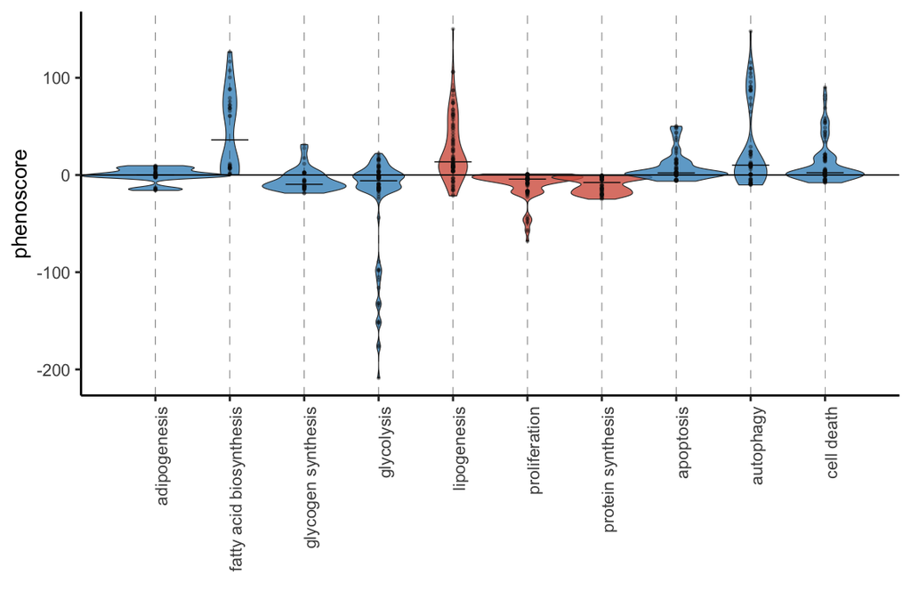

```r
# Read phenotypic gold standard table
read_tsv('./input/gold_standard_pheno.tsv') -> gold_stadard_pheno
gold_stadard_pheno <- gold_stadard_pheno %>% mutate(color = ifelse(gold_standard == -100, '#4393C3', '#D6604D'))

# Read benchmark analysis result
pheno_table <- read_tsv(paste0(pheno_dir, "phenoscore_bench.tsv"))

# Merge the two table
inner_join(pheno_table, gold_stadard_pheno, by = c('phenotype' ='phenotypes')) -> pheno_table

# Violin plot of the whole results
violin_pheno_all <- pheno_table %>% filter(phenotype %in% gold_stadard_pheno$phenotypes) %>%
  ggplot( aes(x=fct_reorder(phenotype, gold_standard), y=phenoscore, fill = phenotype)) +
  #facet_grid( . ~ mf, scales = 'free') +
  geom_violin(width=2, size=0.2, alpha = .8) +
  scale_fill_manual(values = gold_stadard_pheno$color, labels = gold_stadard_pheno$phenotypes) +
  stat_summary(fun = median, geom = "crossbar", width = 0.5, size = 0.1, color = "grey3") +
  geom_point(color = 'grey3', alpha = .3, size = .3) +
  geom_vline(xintercept = pheno_table$phenotype, size = .1, color = 'grey3', linetype = 'dashed') +
  geom_hline(yintercept = 0, size = .3, color = 'grey3') +
  theme_classic() +
  theme(text = element_text(size=10),
        axis.text.x = element_text(angle = 90, hjust = 1, size = 8),
        legend.position="none") +
  xlab("")

violin_pheno_all
```

## Find the best result of phenotypic inference

```r
# Read benchmark analysis result
pheno_table <- read_tsv(paste0(pheno_dir, "phenoscore_bench.tsv"))

# Transform in wide format
pheno_table %>% pivot_wider(
  id_cols = c(phenotype),
  names_from = pheno_id,
  values_from = c(phenoscore)
) -> wide_table

# Read gold standard
read_tsv('./input/gold_standard_pheno.tsv') %>% filter(!is.na(gold_standard)) -> gold_stadard_pheno

# Join wide table and gold standard table and transform it in matrix
inner_join(gold_stadard_pheno, wide_table, by = c('phenotypes' = 'phenotype')) -> wide_table
wide_table_m <- wide_table %>% column_to_rownames('phenotypes')

# Precision, Recall and RMSE computation
results <- lapply(wide_table_m[, -1, drop = FALSE], function(col) {
  compute_auprc(wide_table$gold_standard, col)
})

precision = round(unlist(lapply(results, function(x){x[1]})),2)
recall = round(unlist(lapply(results, function(x){x[2]})),2)

rmse <- lapply(wide_table_m[, -1, drop = TRUE], function(col) {
  compute_rmse(wide_table$gold_standard, col)
})

rmse = unlist(rmse)

# Create a table with type of analyses and precision, recall and RMSE
auprc_df <- tibble(conditions = names(precision),
                   Precision = precision,
                   Recall = recall,
                   RMSE = rmse)

# Add to the metrics table the computation time
inner_join(auprc_df,
           pheno_table %>% select(pheno_id, phenoscore_time) %>% distinct(), by = c('conditions' = 'pheno_id')) -> auprc_df

# Overall metrics table
head(auprc_df)
```

```
## # A tibble: 6 × 5
##   conditions Precision Recall  RMSE phenoscore_time
##   <chr>          <dbl>  <dbl> <dbl>           <dbl>
## 1 Pheno1          0.67    0.2  97.3            22.9
## 2 Pheno2          0.67    0.2  99.0            19.9
## 3 Pheno3          0.71    0.5  99.2            20.6
## 4 Pheno4          0.71    0.5  99.9            20.0
## 5 Pheno5          0.6     0.6 101.             24.0
## 6 Pheno6          0.6     0.6 101.             24.9
```

Here, we define a **combined score for Step3** that weights Precision, Recall, the Root Mean Squared Error (RMSE) RMSE and the computation time. The computation time and RMSE were normalized to be in the same scale as precision and recall.

```r
# Normalize time and RMSE
auprc_df$norm_RMSE <- auprc_df$RMSE / max(auprc_df$RMSE)
auprc_df$norm_time <- auprc_df$phenoscore_time / (max(auprc_df$phenoscore_time))

# Define a score for parameters ranking
auprc_df %>% mutate(score = (Precision + Recall) - (norm_RMSE + norm_time*0.5) ) %>%
  arrange(desc(score)) -> sorted_pheno

#write_tsv(sorted_pheno, file = paste0(pheno_dir, 'phenoscore_metrics_sorted.tsv'))

head(sorted_pheno)
```

```
## # A tibble: 6 × 8
##   conditions Precision Recall  RMSE phenoscore_time norm_RMSE norm_time score
##   <chr>          <dbl>  <dbl> <dbl>           <dbl>     <dbl>     <dbl> <dbl>
## 1 Pheno89         0.8     0.8 100.             18.6     0.760     0.748 0.466
## 2 Pheno88         0.86    0.6  85.7            17.5     0.650     0.705 0.458
## 3 Pheno78         0.8     0.8 101.             18.9     0.763     0.758 0.458
## 4 Pheno87         0.86    0.6  85.7            17.8     0.650     0.714 0.453
## 5 Pheno76         0.86    0.6  85.4            18.0     0.647     0.725 0.450
## 6 Pheno75         0.86    0.6  85.5            18.2     0.649     0.731 0.446
```

The **best result** is Pheno89.

## Establish a default set of parameter for phenotypic inference (Step 3)

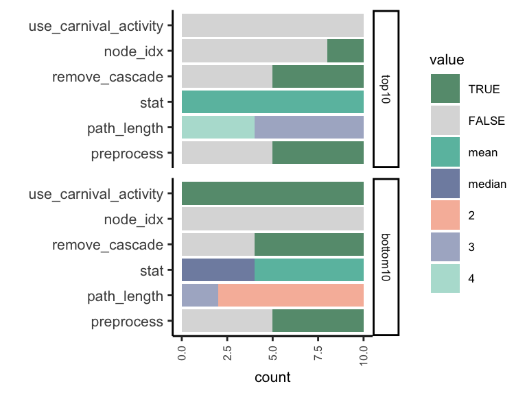

```r
# Read sorted phenotypic results and technical parameters
# associated to each technical condition and merge the tables
sorted_pheno <- read_tsv(paste0(pheno_dir, 'phenoscore_metrics_sorted.tsv'))
phenoscore_params_df <- read_tsv(paste0(pheno_dir, 'pheno_annotation_df.tsv'))

inner_join(sorted_pheno %>%
             select(conditions, score),
           phenoscore_params_df,
           by = c('conditions' = 'pheno_id')) %>%
  arrange(desc(score)) -> sorted_pheno_anno

# Create a table of top10 and bottom10
head(sorted_pheno_anno, n = 10) -> top20
top20$type = 'top10'
tail(sorted_pheno_anno, n = 10) -> bottom20
bottom20$type <- 'bottom10'

bind_rows(top20, bottom20) -> total_phenotypes
total_phenotypes$score <- NULL

total_phenotypes %>% mutate_all(as.character) -> total_phenotypes_anno

# Transform in long format
params_total_phenotypes_anno <- pivot_longer(data = total_phenotypes_anno,
                                           cols = colnames(total_phenotypes_anno)[2:7])

params_total_phenotypes_anno$value <- factor(params_total_phenotypes_anno$value,
                                           levels = c('TRUE', 'FALSE',  'mean',
                                                      'median', '2', '3', '4'))

params_total_phenotypes_anno$name <- factor(params_total_phenotypes_anno$name,
                                          levels = c('preprocess', 'path_length', 'stat',
                                                     'remove_cascade', 'node_idx', 'use_carnival_activity'))

params_total_phenotypes_anno$type <- factor(params_total_phenotypes_anno$type,
                                          levels = c('top10', 'bottom10'))

params_total_phenotypes_anno %>% filter(!is.na(value)) -> params_total_phenotypes_anno



list('#006837', '#CCCCCC', "#00A087", "#3C5488", "#F39B7F", "#8491B4", "#91D1C2") -> color_custom

ggplot(params_total_phenotypes_anno, aes(x = name, fill = value)) +
  geom_bar(stat = 'count', alpha = .7) +
  facet_grid(type~.) +
  scale_fill_manual( values = color_custom) +
  theme_classic() +
  coord_flip()+

  theme(text = element_text(size = 8),
        axis.text.x = element_text(angle = 90, hjust = 1, vjust = .5, size = 6),
        axis.text.y = element_text(angle = 0, size = 8)) +
  xlab('')
```

**Figure S7B** Result of benchmarking of Step3. Distribution of each parameter in the top and bottom 10 phenotypes inference results after ranking 96 produced results based on the combined score that considers coherence with the phenotypic gold standard and computation time (see Methods).